# spamClass

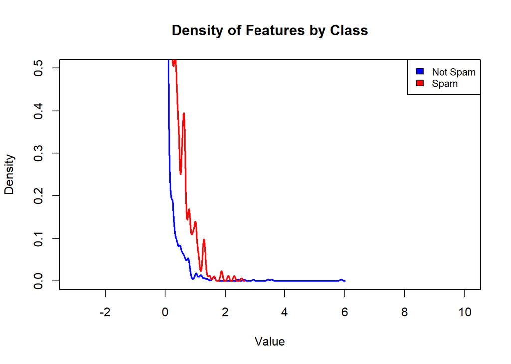

```r
# Assuming 'data' is your dataframe, and it contains a 'spam_target' column
# 'plot.feats' contains the column indices of the features you want to plot

plot.feats <- c(6)  # Example feature columns to plot

# Prepare the plot window
plot(NULL, xlim = c(-3, 10), ylim = c(0, 0.5), # Adjust xlim and ylim as needed
     xlab = "Value", ylab = "Density",
     main = "Density of Features by Class")

# Colors for different classes
colors <- c("blue", "red")

# Loop through the selected features
for (i in plot.feats) {
  # Density estimate for class 0
  density_estimate_0 <- density(data[data$spam_target == 0, i], na.rm = TRUE,from=0)
  lines(density_estimate_0, col = colors[1], lwd = 2)  # lwd is line width

  # Density estimate for class 1
  density_estimate_1 <- density(data[data$spam_target == 1, i], na.rm = TRUE, from=0)
  lines(density_estimate_1, col = colors[2], lwd = 2)

  # Adding a legend only once
  if (i == plot.feats[1]) {
    legend("topright", legend = c("Not Spam", "Spam"), fill = colors, cex = 0.8)
  }
}
```

The last preprocessing steps we take is to scale our predictive features. This helps in fitting regularized logistic regression models like *lasso*, by preventing variable selection bias. To address the issue of our highly skewed data, we transform the predictive features using $\log\text{1p}(x) = \log(1+x)$. This transformation was chosen for its ability to map examples taking a wide range of values to a more reasonable interval while a good degree of variation in examples close to 0. Additional, since the input of the the logarithm is strictly positive, there are no issues with the output being either negative or undefined. To test the effectiveness of this transformation, we preserved an untransformed dataset which we will use for comparison. We apply standard (z) scaling to both our transformed and and untransformed datasets. As an outcome of this all predictive features will have mean $0$ and variance $1$.

```r
data.trans <- data # mitigate tailedness by transforming data
# log1p squashes positive reals (no issues with negative or undefined outputs)
data.trans[,1:57] <- log1p(data[,1:57])
data.trans.scaled <- data.trans
data.trans.scaled[,1:57] <- scale(data.trans.scaled[,1:57]) # don't scale spam_target
data.scaled <- data # untranslated data for comparison
data.scaled[,1:57] <- scale(data.scaled[,1:57]) # don't scale spam_target
```

We can see how these transformations have effected the population statistics of our representative features.

```r
freq.feats <- c("word_freq_you","word_freq_money","word_freq_free", "char_freq_$","char_freq_[")
org.stats <- cbind(describe(data[freq.feats]), set=rep("org",5))[c("set","mean","median","sd","min","max","range","skew","kurtosis")]
scaled.stats <- cbind(describe(data.scaled[freq.feats]),set=rep("scaled",5))[c("set","mean","median","sd","min","max","range","skew","kurtosis")]
scaled.trans.stats <- cbind(describe(data.trans.scaled[freq.feats]),set=rep("scaled.trans",5))[c("set","mean","median","sd","min","max","range","skew","kurtosis")]
all.stats <- rbind(org.stats,scaled.stats,scaled.trans.stats)
print(all.stats[rep(c(1,6,11),5) + rep(0:4, each = 3),])
```

```
##                           set          mean      median        sd        min
## word_freq_you             org  1.662100e+00  1.31000000 1.7754807  0.0000000
## word_freq_you1         scaled -3.614915e-17 -0.19831224 1.0000000 -0.9361406
## word_freq_you2   scaled.trans -1.505337e-17  0.09870491 1.0000000 -1.2053150
## word_freq_money           org  9.426864e-02  0.00000000 0.4426355  0.0000000
## word_freq_money1       scaled -1.510465e-17 -0.21297124 1.0000000 -0.2129712
## word_freq_money2 scaled.trans  3.061487e-18 -0.32678917 1.0000000 -0.3267892
## word_freq_free            org  2.488481e-01  0.00000000 0.8257917  0.0000000
## word_freq_free1        scaled  6.306847e-18 -0.30134485 1.0000000 -0.3013449
## word_freq_free2  scaled.trans  2.262548e-17 -0.45227224 1.0000000 -0.4522722
## char_freq_$               org  7.581069e-02  0.00000000 0.2458820  0.0000000
## char_freq_$1           scaled -2.127158e-17 -0.30832143 1.0000000 -0.3083214
## char_freq_$2     scaled.trans -6.392752e-18 -0.41680695 1.0000000 -0.4168069
## char_freq_[               org  1.697587e-02  0.00000000 0.1093942  0.0000000
## char_freq_[1           scaled -2.436469e-17 -0.15518081 1.0000000 -0.1551808
## char_freq_[2     scaled.trans -2.064503e-17 -0.21263672 1.0000000 -0.2126367
##                        max     range       skew   kurtosis
## word_freq_you    18.750000 18.750000  1.5906366   5.246793
## word_freq_you1    9.624380 10.560521  1.5906366   5.246793
## word_freq_you2    3.440971  4.646286  0.1551522  -1.157777
## word_freq_money  12.500000 12.500000 14.6774530 301.594507
## word_freq_money1 28.026967 28.239938 14.6774530 301.594507
## word_freq_money2 13.253238 13.580027  5.0115888  37.773780
## word_freq_free   20.000000 20.000000 10.7565768 196.123693
## word_freq_free1  23.917838 24.219183 10.7565768 196.123693
## word_freq_free2   8.985530  9.437802  3.0218119  11.673713
## char_freq_$       6.003000  6.003000 11.1558634 199.647043
## char_freq_$1     24.105827 24.414149 11.1558634 199.647043
## char_freq_$2     13.160118 13.576924  4.5885255  33.542579
## char_freq_[       4.081000  4.081000 21.0697997 617.532574
## char_freq_[1     37.150283 37.305464 21.0697997 617.532574
## char_freq_[2     24.551074 24.763711 11.1902137 188.841331
```

The above table displays skew and kurtosis values much lower for the transformed datasets. The effect of this will be tested in the next section.